# rbiips: Tutorial 2

In this tutorial, we consider applying sequential Monte Carlo methods for sensitivity analysis and parameter estimation in a nonlinear non-Gaussian hidden Markov model.

# Statistical model

The statistical model is defined as follows.

$$x_1\sim \mathcal N\left (\mu_0, \frac{1}{\lambda_0}\right )$$

$$y_1\sim \mathcal N\left (h(x_1), \frac{1}{\lambda_y}\right )$$

For $t=2:t_{max}$

$$x_t|x_{t-1} \sim \mathcal N\left ( f(x_{t-1},t-1), \frac{1}{\lambda_x}\right )$$

$$y_t|x_t \sim \mathcal N\left ( h(x_{t}), \frac{1}{\lambda_y}\right )$$

$$\log(\lambda_y) \sim Unif(-3,3)$$

# Statistical model in BUGS language

We describe the model in BUGS language in the file `'hmm_1d_nonlin_param.bug'`:

```r
model_file = 'hmm_1d_nonlin_param.bug' # BUGS model filename
cat(readLines(model_file), sep = "\n")
```

```
var x_true[t_max], x[t_max], y[t_max]

data
{
  #log_prec_y_true ~ dunif(-3, 3)
  prec_y_true <- exp(log_prec_y_true)
  x_true[1] ~ dnorm(mean_x_init, prec_x_init)
  y[1] ~ dnorm(x_true[1]^2/20, prec_y_true)
  for (t in 2:t_max)
  {
    x_true[t] ~ dnorm(0.5*x_true[t-1]+25*x_true[t-1]/(1+x_true[t-1]^2)+8*cos(1.2*(t-1)), prec_x)
    y[t] ~ dnorm(x_true[t]^2/20, prec_y_true)
  }
}

model
{
  log_prec_y ~ dunif(-3, 3)
  prec_y <- exp(log_prec_y)
  x[1] ~ dnorm(mean_x_init, prec_x_init)
  y[1] ~ dnorm(x[1]^2/20, prec_y)
  for (t in 2:t_max)
  {
    x[t] ~ dnorm(0.5*x[t-1]+25*x[t-1]/(1+x[t-1]^2)+8*cos(1.2*(t-1)), prec_x)
    y[t] ~ dnorm(x[t]^2/20, prec_y)
  }
}
```

3. Load rbiips package

```r
require(rbiips)
```

# General settings

```r
par(bty='l')
light_blue = rgb(.7, .7, 1)
light_red = rgb(1, .7, .7)
```

Set the random numbers generator seed for reproducibility

```r
set.seed(2)
```

# Load model and data

#### Model parameters

```r
t_max = 20
mean_x_init = 0
prec_x_init = 1/5
prec_x = 1/10
log_prec_y_true = log(1) # True value used to sample the data
data = list(t_max=t_max, prec_x_init=prec_x_init,
            prec_x=prec_x, log_prec_y_true=log_prec_y_true,
            mean_x_init=mean_x_init)
```

#### Compile BUGS model and sample data

```r
sample_data = TRUE # Boolean
model = biips_model(model_file, data, sample_data=sample_data) # Create Biips model and sample data
```

```
* Parsing model in: hmm_1d_nonlin_param.bug
* Compiling data graph
  Declaring variables
  Graph size: 280
  Sampling data
  Reading data back into data table
  Declaring variables
  Graph size: 284
```

```r
data = model$data()
```

# Biips Sensitivity analysis with Sequential Monte Carlo

Let now use Biips to provide estimates of the marginal log-likelihood and penalized marginal log-likelihood given various values of the log-precision parameters $\log(\lambda_y)$.

#### Parameters of the algorithm

```r
n_part = 100 # Number of particles
# Range of values of the parameter for which we want to study sensitivity
param_values = list(log_prec_y = seq(-5,3,.2))
```

#### Run sensitivity analysis with SMC

```r
out_sens = biips_smc_sensitivity(model, param_values, n_part)
```

```
* Analyzing sensitivity with 100 particles
  |**************************************************| 41 iterations in 0.63 s
```

#### Plot log-marginal likelihood and penalized log-marginal likelihood

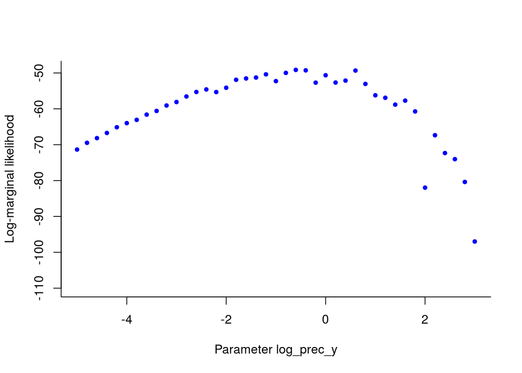

Log-marginal likelihood

```r
plot(param_values[[1]], out_sens$log_marg_like, col='blue', pch=20,
     xlab ='Parameter log_prec_y',
     ylab = 'Log-marginal likelihood',
     ylim=c(-110, max(out_sens$log_marg_like)))
```

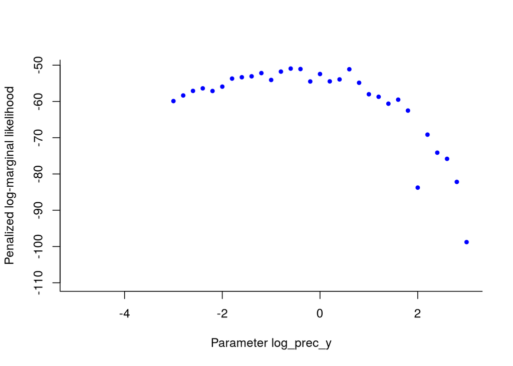

Penalized log-marginal likelihood

```r
plot(param_values[[1]], out_sens$log_marg_like_pen, col='blue', pch=20,
     xlab ='Parameter log_prec_y',
     ylab = 'Penalized log-marginal likelihood',
     ylim=c(-110, max(out_sens$log_marg_like_pen)))
```

# Biips Particle Marginal Metropolis-Hastings

We now use Biips to run a Particle Marginal Metropolis-Hastings in order to obtain posterior MCMC samples of the parameter and the variables $x$.

#### Parameters of the PMMH

`param_names` indicates the parameters to be sampled using a random walk Metroplis-Hastings step. For all the other variables, Biips will use a sequential Monte Carlo as proposal.

```r
n_burn = 2000 # nb of burn-in/adaptation iterations
n_iter = 2000 # nb of iterations after burn-in
thin = 1 # thinning of MCMC outputs
n_part = 50 # nb of particles for the SMC
var_name = 'log_prec_y'
param_names = c(var_name) # name of the variables updated with MCMC (others are updated with SMC)
latent_names = c('x') # name of the variables updated with SMC and that need to be monitored
```

#### Init PMMH

```r
obj_pmmh = biips_pmmh_init(model, param_names, inits=list(log_prec_y=-2),
                     latent_names=latent_names) # creates a pmmh object
```

```
* Initializing PMMH
```

#### Run PMMH

```r
biips_pmmh_update(obj_pmmh, n_burn, n_part) # adaptation and burn-in iterations
```

```
* Adapting PMMH with 50 particles
  |++++++++++++++++++++++++++++++++++++++++++++++++++| 2000 iterations in 13.93 s
```

```r
out_pmmh = biips_pmmh_samples(obj_pmmh, n_iter, n_part, thin=thin) # samples
```

```
* Generating 2000 PMMH samples with 50 particles
  |**************************************************| 2000 iterations in 13.59 s
```

#### Some summary statistics

```r
summ_pmmh = biips_summary(out_pmmh, probs=c(.025, .975))
```

#### Compute kernel density estimates

```r
kde_pmmh = biips_density(out_pmmh)
```

#### Posterior mean and credible interval of the parameter

```r
summ_param = summ_pmmh[[var_name]]
cat('Posterior mean of ', var_name, ':', summ_param$mean, '\n');
```

```
Posterior mean of  log_prec_y : -0.4406997
```

```r
cat('95% credible interval of ', var_name, ': [', summ_param$quant[[1]], ', ', summ_param$quant[[2]],']\n', sep='')
```

```
95% credible interval of log_prec_y: [-1.661505, 0.6949494]
```

#### Trace of MCMC samples of the parameter

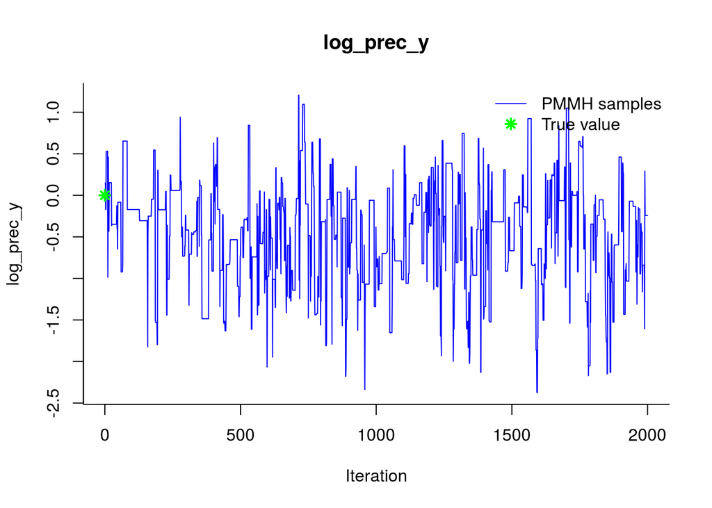

PMMH: Trace samples parameter

```r
samples_param = out_pmmh[[var_name]]
plot(samples_param[1,], col='blue', type='l', lwd=1,
     xlab='Iteration',
     ylab=var_name,
     main=var_name)
points(0, log_prec_y_true, col='green', pch=8, lwd=2)
legend('topright', leg=c('PMMH samples', 'True value'),
       col=c('blue', 'green'), pch=c(NA,8), lwd=c(1,2), lty=c(1,NA),
       bty='n')
```

#### Histogram and KDE estimate of the posterior for the parameter

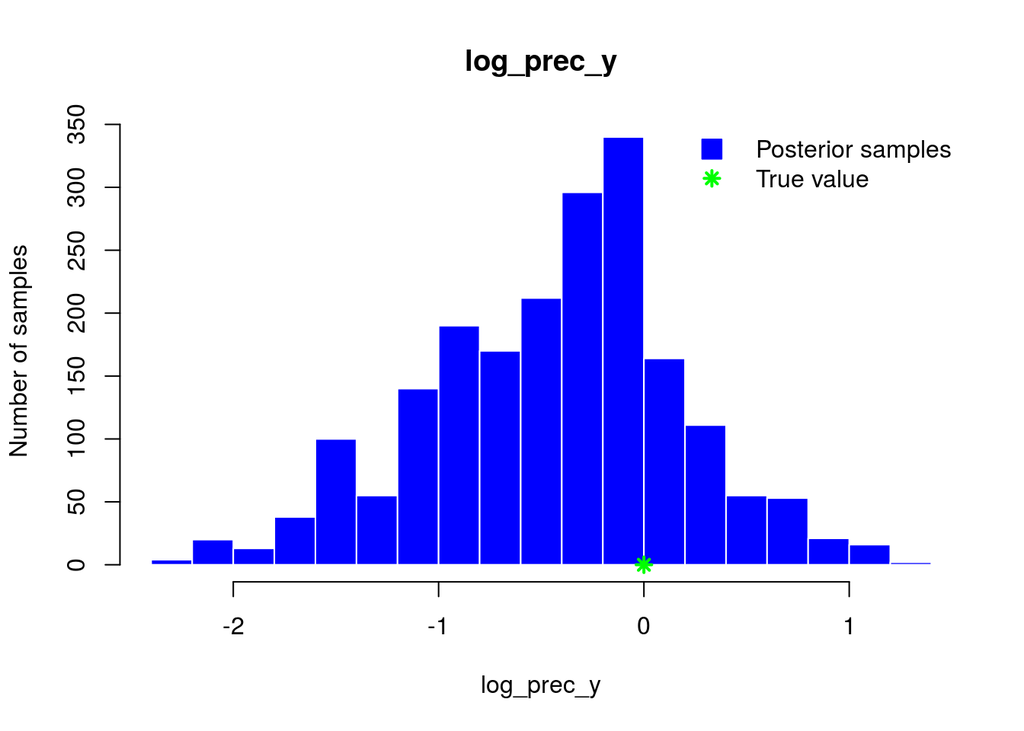

PMMH: Histogram posterior parameter

```r
hist(samples_param, breaks=15, col='blue', border='white',
     xlab=var_name, ylab='Number of samples',
     main=var_name)
points(log_prec_y_true, 0, col='green', pch=8, lwd=2)
legend('topright', leg=c('Posterior samples', 'True value'),
       col=c('blue', 'green'), pch=c(22,8), lwd=c(NA,2), lty=NA, pt.cex=c(2,1), pt.bg=c(4,NA),
       bty='n')
```

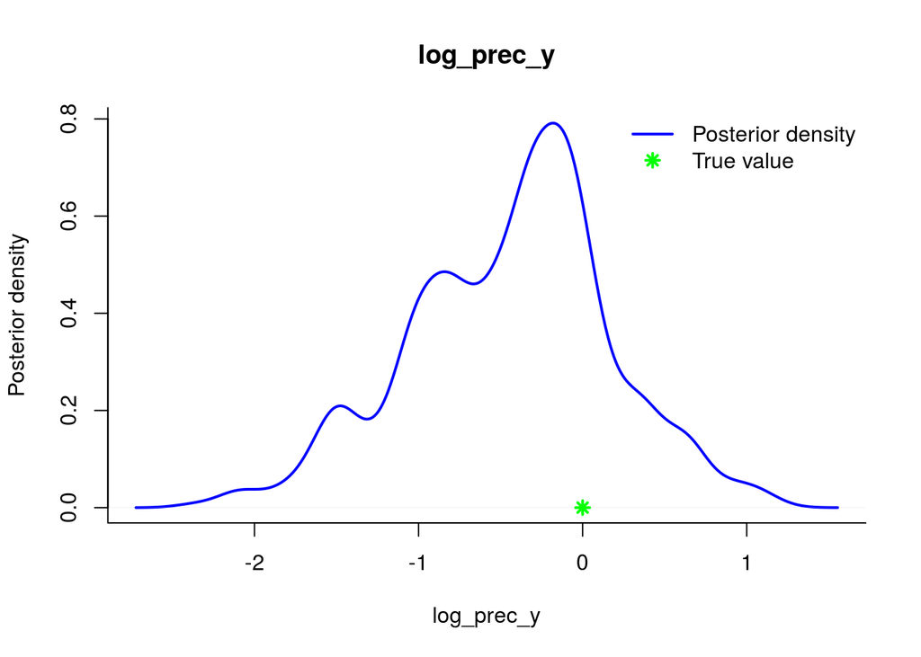

PMMH: KDE estimate posterior parameter

```r
kde_param = kde_pmmh[[var_name]]
plot(kde_param, col='blue', lwd=2,
     xlab=var_name, ylab='Posterior density',
     main=var_name)
points(log_prec_y_true, 0, col='green', pch=8, lwd=2)
legend('topright', leg=c('Posterior density', 'True value'),
       col=c('blue', 'green'), pch=c(NA,8), lty=c(1,NA), lwd=2,
       bty='n')
```

#### Posterior mean and quantiles for x

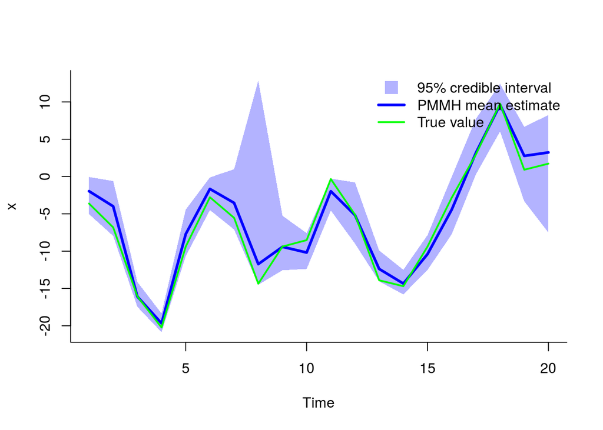

PMMH: Posterior mean and quantiles

```r
x_pmmh_mean = summ_pmmh$x$mean
x_pmmh_quant = summ_pmmh$x$quant

xx = c(1:t_max, t_max:1)
yy = c(x_pmmh_quant[[1]], rev(x_pmmh_quant[[2]]))
plot(xx, yy, type='n', xlab='Time', ylab='x')

polygon(xx, yy, col=light_blue, border=NA)
lines(1:t_max, x_pmmh_mean, col='blue', lwd=3)
lines(1:t_max, data$x_true, col='green', lwd=2)
legend('topright', leg=c('95% credible interval', 'PMMH mean estimate', 'True value'),
       col=c(light_blue,'blue','green'), lwd=c(NA,3,2), pch=c(15,NA,NA), pt.cex=c(2,1,1),
       bty='n')
```

#### Trace of MCMC samples for x

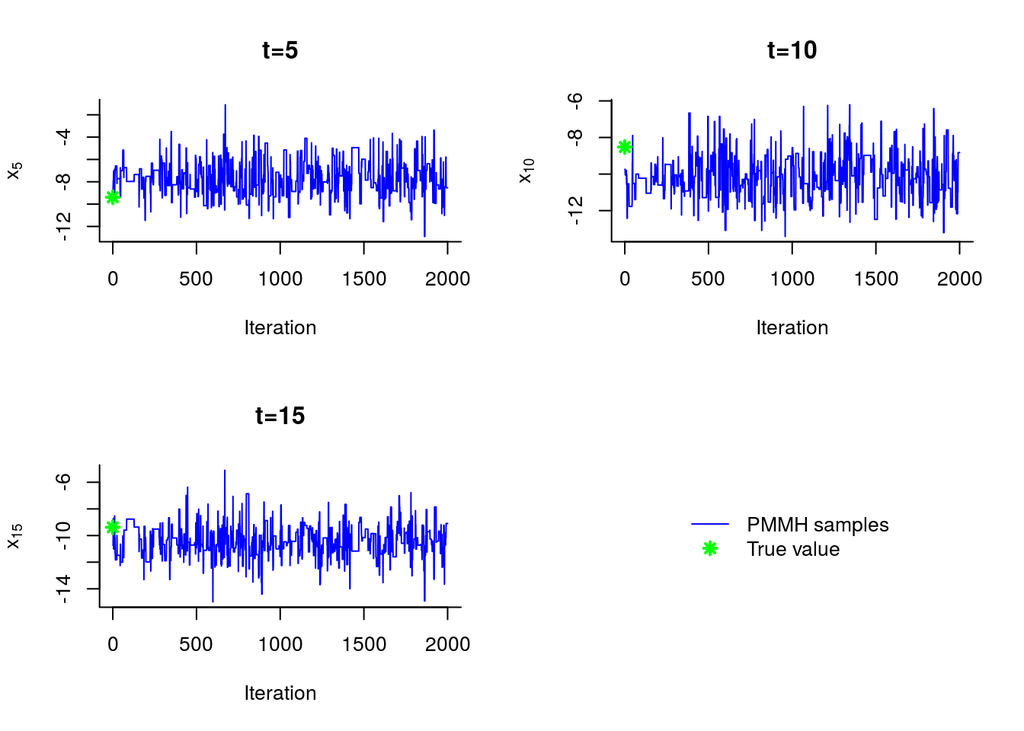

PMMH: Trace samples x

```r
time_index = c(5, 10, 15)
par(mfrow=c(2,2))
for (k in 1:length(time_index)) {
  tk = time_index[k]
  plot(c(out_pmmh$x[tk,]), col='blue', type='l', lwd=1,
       xlab='Iteration',
       ylab=bquote(x[.(tk)]),
       main=paste('t=', tk, sep=''))
  points(0, data$x_true[tk], col='green', pch=8, lwd=2)
}
plot(0, type='n', bty='n', xaxt='n', yaxt='n', xlab="", ylab="")
legend('center', leg=c('PMMH samples', 'True value'),
       col=c('blue', 'green'), pch=c(NA,8), lty=c(1,NA), lwd=c(1,2),
       bty='n')
par(mfrow=c(1,1))
```

#### Histogram and kernel density estimate of posteriors of x

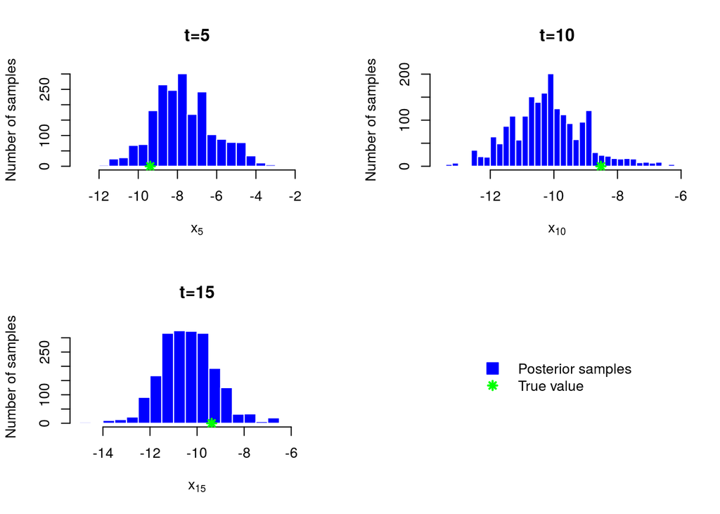

PMMH: Histograms marginal posteriors

```r
par(mfrow=c(2,2))
for (k in 1:length(time_index)) {
  tk = time_index[k]
  hist(out_pmmh$x[tk,], breaks=30, col='blue', border='white',
       xlab=bquote(x[.(tk)]),
       ylab='Number of samples',
       main=paste('t=', tk, sep=''))
  points(data$x_true[tk], 0, col='green', pch=8, lwd=2)
}
plot(0, type='n', bty='n', xaxt='n', yaxt='n', xlab="", ylab="")
legend('center', leg=c('Posterior samples', 'True value'),
       col=c('blue', 'green'), pch=c(22,8), lwd=c(1,2), lty=NA, pt.cex=c(2,1), pt.bg=c(4,NA),
       bty='n')
par(mfrow=c(1,1))
```

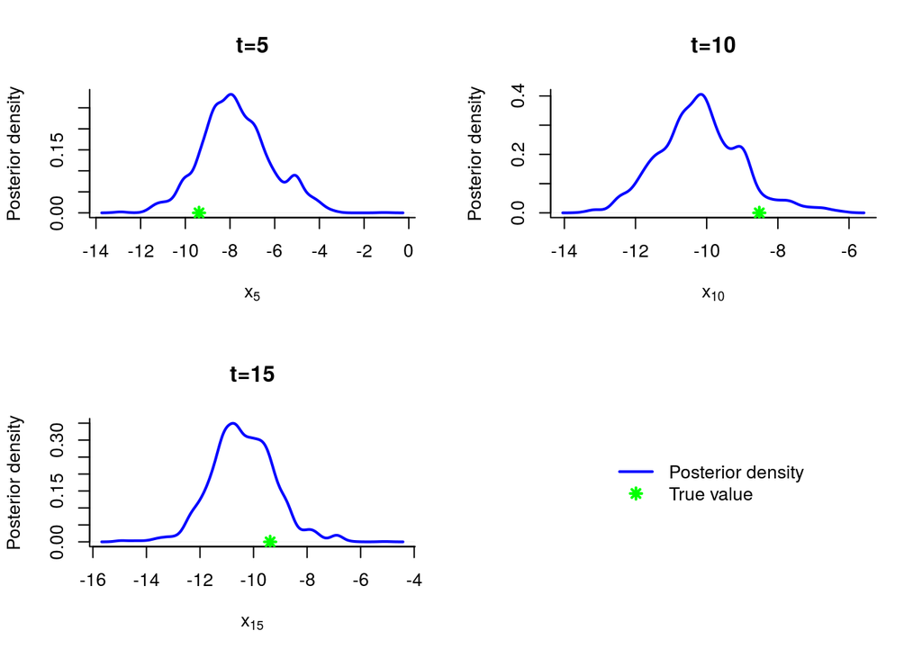

PMMH: KDE estimates marginal posteriors

```r
par(mfrow=c(2,2))
for (k in 1:length(time_index)) {
  tk = time_index[k]
  plot(kde_pmmh$x[[tk]], col='blue', lwd=2,
       xlab=bquote(x[.(tk)]),
       ylab='Posterior density',
       main=paste('t=', tk, sep=''))
  points(data$x_true[tk], 0, col='green', pch=8, lwd=2)
}
plot(0, type='n', bty='n', xaxt='n', yaxt='n', xlab="", ylab="")
legend('center', leg=c('Posterior density', 'True value'),
       col=c('blue', 'green'), pch=c(NA,8), lwd=2, lty=c(1,NA), pt.cex=c(2,1), pt.bg=c(4,NA),
       bty='n')
par(mfrow=c(1,1))
```